# SPI Database Data Dictionary

06/01/2023

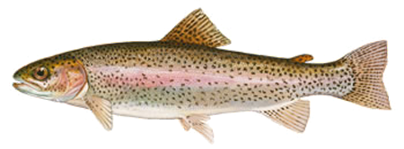

# **Database Overview**

#### Disclaimer

The Salmonid Population Indicators (SPI) database is a work in progress and is subject to change.

### Salmonid Population Indicators (SPI) Database

Since its genesis as the Salmon and Steelhead Stock Inventory (SASSI) in 1992 and then the Salmonid Stock Inventory (SaSI) in 1998, the Salmonid Population Indicators (SPI) database has consisted of:

1. A standardized, uniform approach to identifying and monitoring the status of Washington’s naturally spawning salmonid populations of hatchery and natural-origin fish.
2. The official list of salmonid populations recognized by the Washington Department of Fish and Wildlife and its co-managers.
3. A database containing population status monitoring information and various metadata relevant to the constituent populations.

SPI is a cooperative product of the Washington Department of Fish and Wildlife and tribal co-managers and was intended to serve as a tool for prioritizing recovery efforts and measuring the results of recovery actions statewide. The co-managers’ original intent was to regularly update and revise the SaSI documents and, with the 1999 creation of the Salmonid Stock Conservation Biology Unit in the Fish Program, a comprehensive updating and revision of the SaSI documents was completed in 2002. In 2022 major changes were made to SPI’s database structure and a new web-based data entry application was created. Additional fields were added based on StreamNet’s Coordinated Assessments Natural Origin Spawner Abundance (CA\NOSA) data exchange format. This latest addition is to provide a salmonid abundance dataset that contains better metadata and more monitoring parameters for more in-depth analysis.

### SPI Core Tables Schema

**What are the core tables in the SPI database?** SPI core data tables include stock, stocK_data_series, and annual_data_detail.

1. Stock contains general descriptions and metadata about the salmonid populations within Washington. It is currently read-only and is populated by the SPI data manager.
2. Stock data series describes the data in annual data detail. It is currently read-only and is populated by the SPI data manager.
3. Annual data detail contains the indicator data and supporting metrics. When data providers enter data in the “Annual Data Entry” page of the SPI Web Funnel, this is where the data is stored.

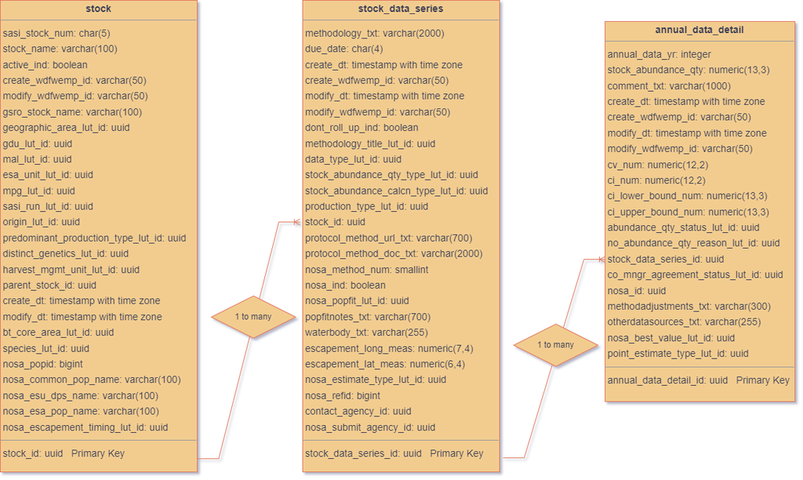

### Database statistics

**How much data is being entered in SPI?** Counts of records in specific tables are indicated in the corresponding sections later in this document. The following plot shows trends of monthly abundance data counts made since 2008.

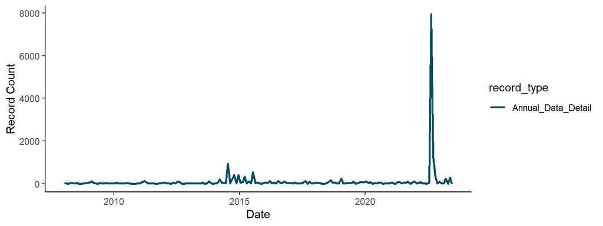

**Where are SPI Populations located?** The following map shows where SPI Populations are located. This section is still under development!!!

[interactive chart not shown]

### SPI Front End Application

SPI data providers can be granted access to a front end web application at: https://apps.wdfw-fish.us. This application allows users to check, add, edit, and delete abundance data. Access to data is limited to populations to which users are assigned.

### Public Data Portal

SPI data contained in this system is mirrored on the WDFW open data portal at https://www.data.wa.gov. These datasets can be accessed directly through the public web portal, or via API. Data is refreshed in this system nightly.

### Contact Information

For more information, please contact the SPI data manager Gil Lensegrav at gilbert.lensegrav@dfw.wa.gov .

# **stock**

This table contains data that is descriptive in nature to individual salmonid populations. It is the primary table and is used to link to other databases or tables and provides a master list of all active or inactive salmonid populations. Linked to stock_data_series, nosa_event, stock_par_assignment, stock_report, management_goal (stock_id).

Total Records: **750**

| FieldName | Nullable? | DataType | Descr |
| --- | --- | --- | --- |
| sasi_stock_num | no | character | 4 digit numeric designation for each individual stock. Typically used for sorting purposes. |
| stock_name | yes | character varying | Name of stock or population. In most cases the NOAA recognized population name is used. |
| active_ind | no | boolean | Indicates if record is active in the current dataset. |
| gsro_stock_name | yes | character varying | Population name used for the Governor’s State of the Salmon Report. |
| stock_id | no | uuid | PK |
| geographic_area_lut_id | no | uuid | The information in this field represents the geographical areas where each individual salmonid stock resides and/or utilizes watersheds throughout Washington State. Link to geographic_area_lut. See ge… |
| gdu_lut_id | yes | uuid | Genetic Diversity Unit (GDU) to which the stock belongs. GDUs are groups of genetically similar stocks. Link to gdu_lut. See gdu_lut. |
| mal_lut_id | yes | uuid | Major Ancestral Lineage (MAL) to which the stock belongs. MALs are groups of similar GDUs. Link to mal_lut. See mal_lut |
| esa_unit_lut_id | yes | uuid | This field defines the units of organization that are used for listing and delisting species under the Endangered Species Act (ESA). Link to esa_unit_lut. See esa_unit_lut. |
| mpg_lut_id | yes | uuid | Major Population Group (MPG) to which the stock belongs. National Marine Fisheries Service Technical Recovery Team’s grouping unit of fish population based on genetic measures, major habitat patterns … |
| sasi_run_lut_id | no | uuid | Return time to freshwater. Most commonly used are spring, summer, fall, late fall, winter, spring/summer, summer/fall. Link to run_time_lut. See run_time_lut. |
| origin_lut_id | no | uuid | Description of the genetic history or heritage of the stock. Link to origin_lut. See origin_lut. |
| predominant_production_type_lut_id | no | uuid | Link to production_type_lut. See production_type_lut. Predominant method of spawning and rearing that produces the fish for the stock. |
| distinct_genetics_lut_id | yes | uuid | Holds information on the distinctiveness of the genetics of a stock. Link to distinct_genetics_lut. See distinct_genetics_lut. |
| harvest_mgmt_unit_lut_id | yes | uuid | Harvest Management Units are geographic areas with common harvest management goals for a given species spawning in the region. Link to harvest_mgmt_unit_lut. See harvest_mgmt_unit_lut. |
| parent_stock_id | yes | uuid | For linking sub-populations to the parent population’s stock_id. |
| bt_core_area_lut_id | no | uuid | Bull trout core area, as defined by USFWS. Specific for bull trout. Link to bt_core_area_lut_id. See related table. |
| species_lut_id | no | uuid | This field defines individual salmonid species. Link to species_lut. See species_lut for values. |
| nosa_popid | yes | bigint | NOSA population id for the population(s) of fish represented by this record. For CA/NOSA data exchange purposes. |
| nosa_common_pop_name | yes | character varying | Population name used by local biologists. |
| nosa_esu_dps_name | yes | character varying | NA |
| nosa_esa_pop_name | yes | character varying | NA |
| nosa_escapement_timing_lut_id | yes | uuid | NA |

# **annual_data_detail**

This table contains annual data that is collected to monitor individual salmonid populations. The data reflects the best estimate of the overall health of the population. Linked to stock_data_series (fk stock_data_series_id).

Total Records: **24891**

| FieldName | Nullable? | DataType | Descr |
| --- | --- | --- | --- |
| annual_data_yr | no | integer | Beginning year in which the data was collected, compiled, or reported. Example: stocks that runin 2005 or from 2005-2006 would have Annual_Data_Yr=2005. Format: YYYY. |
| stock_abundance_qty | yes | numeric | Contains a value reported by regional biologists as being the most current data for the associated stock. This value is used to chart current abundance trends and rate stock status for individual salm… |
| comment_txt | yes | character varying | Comments related directly to the relevant annual_data_detail_d record. Example: observational data; i.e. high water, low visibility. |
| cv_num | yes | numeric | Coefficient of variation for the associated stock_abundance_qty. Coefficient of variation is the ratio between the standard deviation and the mean. |
| ci_num | yes | numeric | Confidence interval for the associated stock_abundance_qty. Express these values as alpha values. For example, for the 95% confidence limits enter “0.05” in this field, not “95”. |
| ci_lower_bound_num | yes | numeric | The lower limit of the confidence interval. Minimum value = 0. If the calculated lower limit of the confidence interval is less than zero you may report 0 in this field, but we suggest you consider st… |
| ci_upper_bound_num | yes | numeric | The upper limit of the confidence interval. Minimum value = 0. |
| annual_data_detail_id | no | uuid | PK |
| abundance_qty_status_lut_id | no | uuid | Describes the quality or status of the stock_abundance_qty value. |
| no_abundance_qty_reason_lut_id | no | uuid | Describes the reason why stock_abundance_qty is left blank or null. |
| stock_data_series_id | no | uuid | FK |
| co_mngr_agreement_status_lut_id | yes | uuid | Describes whether the stock_abundance_qty was agreed-to by co-managers who are involved in the calculation process. |
| nosa_id | yes | uuid | Used for StreamNet’s external data submissions, specifically the NOSA table. |
| methodadjustments_txt | yes | character varying | Minor adjustments to a method in a given year that are not described in the methodology fields in the stock_data_series table but are important. |
| otherdatasources_txt | yes | character varying | Identifies additional organizations, not listed in the stock_data_series table, that provided data or expertise to calculate the indicator(s), metric(s), or age distribution for this record. |
| nosa_best_value_lut_id | yes | uuid | A declaration of whether the stock_data_series ContactAgency considers this record to be their approved best estimate for this combination of PopID and SpawningYear. |
| point_estimate_type_lut_id | yes | uuid | NA |

### abundance_qty_status_lut

Describes the most current status of the stock abundance quantity.

| abundance_qty_status_short_desc | abundance_qty_status_desc |
| --- | --- |
| Draft | Values in this record are preliminary and have not been thoroughly reviewed. |
| Final | Values in this record have been thoroughly reviewed and are considered final. |
| Reviewed | Values in this record have been reviewed but are not yet approved as final. |
| Unknown | Unknown status. |

### no_abundance_qty_reason_lut

Describes the reason why the Abundance_Qty field is left blank or null. The information is needed for data accountability reasons.

| reason_short_desc | reason_desc |
| --- | --- |
| Estimate Pending | Data collection/analysis is pending and an estimate will be generated as soon as possible. |
| N | Not applicable (estimate received) |
| No Data | No data was collected for this data type this year. |
| No Estimate | Data were collected but no estimate can be generated. The nature of the data should be entered into the comments field. |
| Unknown(historical) | Unknown; to be used for historical records only |

### co_mngr_agreement_status_lut

Describes whether an abundance estimate is agreed to by co-managers. Co-managers may be tribal, contractual, or public agency.

| co_mngr_agreement_status_short_desc | co_mngr_agreement_status_desc |
| --- | --- |
| agreed-to | Abundance quantity was agreed-to by co-managers. |
| N | Not applicable |
| not agreed-to | Abundance quantity was not agreed-to by co-managers. |
| unknown | Unknown whether the abundance quantity was agreed-to by co-managers. |

### nosa_best_value_lut

A declaration of whether the source agency considers a record to be their approved best estimate for this combination of stock and annual data year.

| best_value_short_desc | best_value_desc |
| --- | --- |
| No | Not recognized as the best estimate provided by that entity. |
| Not specified | Best value status not specified |
| Yes | The entity (tribe, state agency, etc.) that created this record recognizes it as their approved best estimate. |

### point_estimate_type_lut

Describes the type of sample data used to calculate a single value abundance quantity point estimate.

| point_estimate_type_short_desc | point_estimate_type_desc |
| --- | --- |
| mean | The sum of the values divided by the number of values. |
| median | The middle value separating the higher half from the lower half of a data sample, a population, or a probability distribution. |
| mode | The value that appears most often in a set of data values. |

# **stock_data_series**

This table describes the abundance data and differentiates between changes in methodology over time. One population could have many data series. Linked to annual_data_detail and data_series_report_tag (stock_data_series_id) and to stock (fk stock_id).

Total Records: **1816**

| FieldName | Nullable? | DataType | Descr |
| --- | --- | --- | --- |
| methodology_txt | yes | character varying | Free form description of methodology. |
| due_date | yes | character | This value represents the mmdd formatted due date for data. This is used to assist data providers with emailed reminders of when data for their stocks are due. It also an indicator of the most active … |
| dont_roll_up_ind | yes | boolean | NA |
| stock_data_series_id | no | uuid | PK |
| methodology_title_lut_id | no | uuid | This value is for assisting users with front end client readability. Not to be used for any specific analysis. |
| data_type_lut_id | no | uuid | Describes the nature of the data. Each active population that is being monitored has at least one type of data that is entered into the database on an annual basis. |
| stock_abundance_qty_type_lut_id | no | uuid | Describes the quantitative and qualitative indicator type represented by the abundance estimate |
| stock_abundance_calcn_type_lut_id | no | uuid | Describes if the abundance estimate is expanded or modeled from a known quantity. |
| production_type_lut_id | no | uuid | Describes the method of spawning and rearing that produced the fish. |
| stock_id | no | uuid | FK |
| protocol_method_url_txt | yes | character varying | URL(s) for published protocols and methods describing the methodology and documenting the derivation of the indicator. If published in MonitoringMethods.org, this link will provide access to study des… |
| protocol_method_doc_txt | yes | character varying | Citation or documentation that describes the protocol and/or method(s) listed in the ProtMethName field. Include references not documented in MonitoringMethods.org, such as reports, journal articles o… |
| nosa_method_num | yes | smallint | This field represents the method(s) used to calculate the indicator and metrics values for ca-nosa data. |
| nosa_ind | no | boolean | Indicates if this data series is specific for ca-nosa (Coordinated Assessments Natural Origin Spawner Abundance) data. |
| nosa_popfit_lut_id | yes | uuid | Categorization of how well the geographic extent of the NOSA estimate corresponds to the geographic definition of the population. |
| popfitnotes_txt | yes | character varying | Text description of how well the natural origin spawner abundance value corresponds to the defined population, and why the data are not at the scale of a single population. |
| waterbody_txt | yes | character varying | Name of the body of water associated with the time series. This may be any of the following: the name of a fluvial water body; the name of an impounded fluvial water body (reservoir); the name of a le… |
| escapement_long_meas | yes | numeric | This is a negative number. Use three digits left of the decimal point and four digits to the right of the decimal point. For example, if WaterBody = Wind River at Shipherd Falls enter -121.8050. Requi… |
| escapement_lat_meas | yes | numeric | Use two digits left of the decimal point and four digits to the right of the decimal point. For example, if WaterBody = Wind River at Shipherd Falls enter 45.7371. Required if EstimateType = Escapemen… |
| nosa_estimate_type_lut_id | yes | uuid | Whether the values in the NOSAIJ and NOSAEJ fields are classified as spawner abundance or escapement. |
| nosa_refid | yes | bigint | CA-NOSA reference ID. The unique StreamNet reference ID number that identifies the source document or database from which the record was obtained. |
| contact_agency_id | yes | uuid | Agency, tribe, or other entity, or person responsible for these data that is the best contact for questions that may arise about this data record. Linked to agency (FK agency_id). |
| nosa_submit_agency_id | yes | uuid | Initials or acronym for the agency, tribe, or other entity, or name of person, that sends this record of data to the CA-NOSA exchange network node at StreamNet. Note that it is possible for one entity… |

### data_type_lut

The Data Type describes the nature of the data. Each active population that is being monitored has at least one type of data that is entered into the database on an annual basis.

| data_type_short_desc | data_type_desc |
| --- | --- |
| Escapement Fish | Fish that successfully pass through a fishery to reach the spawning grounds. This amount reflects losses resulting from harvest and natural mortality prior to enumeration but does not reflect pre-spaw… |
| HOSAEJ | The point estimate for hatchery origin spawner abundance, excluding jacks. Includes only adults of hatchery origin, excluding jacks. Hatchery origin means the fish’s parents spawned in a hatchery or a… |
| HOSAIJ | The point estimate for hatchery origin spawner abundance, including jacks. Includes adults and jacks, all of hatchery origin. Hatchery origin means the fish’s parents spawned in a hatchery or artifici… |
| HOSJF | Hatchery origin spawner jack fraction. Express these values as numbers from zero to one, with three digits to the right of the decimal point. |
| NA | Not applicable |
| NOBroodStockRemoved | Natural origin broodstock removed. Provide whole numbers only, not decimal values. This value reflects fish taken for hatchery use. If it is known that no broodstock were taken it is preferable to ent… |
| NOSAEJ | The point estimate for natural origin spawner abundance, excluding jacks. Includes only adults of natural origin, excluding jacks. Natural origin means the fish’s parents spawned in the wild. Provide … |
| NOSAIJ | The point estimate for natural origin spawner abundance, including jacks. Includes adults and jacks, all of natural origin. Natural origin means the fish’s parents spawned in the wild. Provide whole n… |
| NOSJF | Natural origin spawner jack fraction. Express these values as numbers from zero to one, with three digits to the right of the decimal point. |
| PHOSEJ | Point estimate for the proportion of fish spawning naturally, excluding jacks, that are hatchery origin fish. Express these values as numbers from zero to one, with up to three digits to the right of … |
| PHOSIJ | Point estimate for the proportion of fish spawning naturally, including jacks, that are hatchery origin fish. Express these values as numbers from zero to one, with up to three digits to the right of … |
| Spawner Fish | Live anddead fish on the spawning grounds. |
| Spawner Redds | Redds on the spawning grounds. |
| TSAEJ | The point estimate for total spawner abundance, excluding jacks. Provide whole numbers only, not decimal values. |
| TSAIJ | The point estimate for total spawner abundance, including jacks. Provide whole numbers only, not decimal values. |
| Unknown | Unknown data type. |

### methodology_title_lut

Methodology titles are used primarily for Web funnel data entrypurposes to help data providers choose which data series to enter data for, increase user-friendliness, and for SCoRE Stock Summary column headings. Use with caution. This field should not be used for detailed analysis.

| methodology_title_short_desc | methodology_title_desc |
| --- | --- |
| Adult Count | Expanded estimate (based on mark-resight) of the abundance of adult fish seasonally staging in a given location before a portion of the population ascends tributaries to spawn. |
| Cumulative Fish*Days | Gen used for live and/or dead counts on the spawning grounds, this is the cumulative total of fish counted throughout the spawning season in fish*days (i.e., before being divided by residence time). |
| Cumulative Redd Count | Cumulative total of redds counted throughout the spawning season in redd*days (i.e., before being divided by redd life). |
| Escapement (Proportion) | Expanded estimate, census, or count of fish escaping past a given location along their migratory path that represents only a portion of escaping abundance for the entire stock and has been separated f… |
| Freshwater Survival | Estimated freshwater survival rate from one life history stage to another. |
| Hatchery Count | Expanded estimate or seasonal census of adult fish counted at a hatchery rack, regardless of origin. |
| Hatchery-Origin Escapement | Expanded estimate or census of the total number of fish of a stock escaping past a given location along their migratory path that are of known hatchery origin. |
| Hatchery-Origin Spawners | Expanded estimate or census of the total number of fish of a stock spawning in the wild that are of known hatchery origin. |
| Hatch-Origin Spawners (Prop.) | Expanded estimate, census, or count of hatchery origin spawners that represents only a portion of spawner abundance for the entire stock and has been separated for management purposes. |
| HOSAEJ | The point estimate for hatchery origin spawner abundance, excluding jacks. Includes only adults of hatchery origin, excluding jacks. |
| HOSAIJ | The point estimate for hatchery origin spawner abundance, including jacks. Includes adults and jacks, all of hatchery origin. |
| HOSA JF | HOSA jack fraction |
| Index Hatchery Escapement | Expanded estimate, census, or count of the number of hatchery fish for a portion of a stock escaping past a given location along their migratory path. |
| Index Hatchery Spawners | Expanded estimate, census, or count of the number of fish for a portion of a stock spawned in a hatchery. |
| Index Natural Escapement | Expanded estimate, census, or count of the number of fish for a portion of a stock escaping past a given location along their migratory path. |
| Index Natural Spawners | Expanded estimate, census, or count of the number of fish for a portion of a stock spawning in the wild. |
| Marine Survival | Estimated marine survival rate from one life history stage to another. |
| Natural-Origin Escapement | Expanded estimate or census of the total number of fish of a stock escaping past a given location along their migratory path that are of known natural origin. |
| Natural-Origin Spawners | Expanded estimate or census of the total number of fish of a stock spawning in the wild that are of known natural origin. |
| Natural-Origin Spawners (Prop) | Expanded estimate, census, or count of natural origin spawners that represents only a portion of spawner abundance for the entire stock and has been separated for management purposes. |
| Natural Spawners (per Mile) | Average number of spawners per mile of spawning ground habitat based on an expanded estimate or census of spawner numbers. |
| No Estimation Method | No standardized annual abundance methodology currently exists for this stock. The stock is either not monitored or data are insufficient to make a valid abundance estimate. |
| NOSA broodstock removed | NOSA number of broodstock removed |
| NOSAEJ | NOSA excluding jacks |
| NOSAIJ | NOSA including jacks |
| NOSA JF | NOSA jack fraction |
| pHOS | Proportion hatchery origin spawners |
| pHOSej | NOSA proportion hatchery origin spawner abundance excluding jacks |
| pHOSij | Proportion hatchery origin spawners including jacks |
| pNOS | Proportion natural original spawners |
| Pre Spawn Mortalities | Count of fish that died prior to spawning. |
| Redd Count (per mile) | Average number of redds per mile of spawning ground habitat based on an expanded estimate or census of redd numbers. |
| Smolts Per Female | Estimated average number of smolts generated per female spawner for a given spawning season. |
| Snorkel Survey | Estimate or census of fish counted via a snorkel survey. |
| SOS 2020 Abundance Analysis | SOS 2020 Abundance Analysis |
| Spawners (Proportion) | Expanded estimate, census, or count of spawners that represents only a portion of spawner abundance for the entire stock and has been separated for management purposes. |
| Total Escapement | Sum total of all fish escaping to a given location along their migratory path that could have (potentially) reached the spawning grounds to contribute to wild production. |
| Total Natural Escapement | Expanded estimate or census of the total number of fish of a stock escaping past a given location along their migratory path, regardless of origin. |
| Total Natural Spawners | Expanded estimate or census of the total number of fish of a stock spawning in the wild, regardless of origin. |
| Trap Count | Expanded estimate or seasonal census of adult fish counted in a trap, regardless of origin. |
| Trap Count (Hatchery-Origin) | Expanded estimate or seasonal census of adult fish counted in a trap that are of known hatchery origin. |
| Trap Count (Natural-Origin) | Expanded estimate or seasonal census of adult fish counted in a trap that are of known natural origin. |
| TSAEJ | NOSA total spawner abundance excluding jacks |
| TSAIJ | NOSA total spawner abundance including jacks |
| Unknown Methodology | Insufficient information to apply a descriptive title. |
| Weir/Lock Count | Expanded estimate or seasonal census of adult fish counted as they pass through a weir or lock. |

### stock_abundance_qty_type_lut

Describes the quantitative and qualitative indicator type represented by the abundance estimate.

| stock_abundance_qty_type_short_desc | stock_abundance_qty_type_desc |
| --- | --- |
| Index | Final reported abundance quantity used to measure relative stock abundance. Only accounts for a portion of a stock’s total abundance. The portion could be (but not limited to) geographic or temporal i… |
| NA | Not applicable |
| Total | Final reported abundance quantity used to measure absolute stock abundance. Applies to the entire geographic area occupied by the stock and represents the stock as a whole. Example: total escapement f… |
| Unknown | Unknown abundance area type. |

### stock_abundance_calcn_type_lut

Describes if the abundance estimate is expanded or modeled from a known quantity.

| stock_abundance_calcn_type_short_desc | stock_abundance_calcn_type_desc |
| --- | --- |
| Expanded | Expanded, modeled, or multiplied from a raw number or quantity that was collected in the field. Example: total escapement modeled using AUC or expanded from raw redd counts using a model or calculatio… |
| NA | Not applicable |
| Unexpanded | The quantity is a raw number or quantity that was collected in the field and is not modeled, expanded, or multiplied in any way. Example: total escapement represented by a raw adult trap fish count. |
| Unknown | Unknown abundance calculation type. |

### production_type_lut

Describes the method of spawning and rearing that produced the fish.

| production_type_short_desc | production_type_desc |
| --- | --- |
| Composite | Mix of Natural and Hatchery production types. Both natural and hatchery components must be confirmed to be present but their proportions are not quantifiable. |
| Hatchery | Spawned, incubated, hatched, or reared in a hatchery or other artificial production facility such as a spawning channel or spawning beach. |
| NA | Not applicable |
| Natural | Spawned and reared in the natural habitat, regardless of parentage (includes native, non-native and mixed stock origin). |
| Unknown | Unknown production type. |

### nosa_popfit_lut

Categorization of how well the geographic extent of the abundance estimate corresponds to the geographic definition of the population. Used for NOSA data exchange purposes.

| nosa_popfit_short_desc | nosa_popfit_desc |
| --- | --- |
| Multiple | Estimate is from more than one population. |
| Portion | Estimate represents a portion of one population. |
| Same | Estimate represents one entire population, the whole population, and nothing but the population. |

### nosa_estimate_type_lut

Whether the values in the NOSAIJ and NOSAEJ fields are classified as spawner abundance or escapement.

| nosa_estimate_type_short_desc | nosa_estimate_type_desc |
| --- | --- |
| Escapement | The number of natural origin fish returning to spawn that pass upstream of a specified location during a specified time period. Includes fish harvested and pre-spawn mortalities that occurred after pa… |
| N | Not applicable |
| NOSA | The number of live natural origin fish available to participate in natural spawning during the spawning period. Prespawn morts (fish that returned but died before spawning) are not included in this nu… |
| Unk | Unknown |

# **stock_report**

The data in this table is used primarily for the SCoRE (online web application) Stock Summary display purposes. Linked to stock (FK stock_id).

Total Records: **621**

| FieldName | Nullable? | DataType | Descr |
| --- | --- | --- | --- |
| stock_definition_txt | yes | character varying | NA |
| origin_txt | yes | character varying | NA |
| genetics_txt | yes | character varying | NA |
| habitat_txt | yes | character varying | NA |
| harvest_txt | yes | character varying | NA |
| hatchery_txt | yes | character varying | NA |
| data_collection_method_txt | yes | character varying | NA |
| spawning_distribution_txt | yes | character varying | NA |
| stock_report_id | no | uuid | PK |
| stock_id | no | uuid | FK |

# **stock_par_assignment**

Cross table link to stock (fk stock_id) and sasi_stock_par (fk par_id). More than one person could be responsible for providing one population’s data, and one person could be responsible for providing more than one populations’ data.

Total Records: **2243**

| FieldName | Nullable? | DataType | Descr |
| --- | --- | --- | --- |
| begin_date | no | timestamp without time zone | Date that data providers were assigned reponsibility for reporting the stock’s data. |
| end_date | yes | timestamp without time zone | Date that data providers assigned reponsibility for reporting the stock’s data ended. |
| stock_par_assignment_id | no | uuid | PK |
| stock_id | yes | uuid | NA |
| par_id | yes | uuid | NA |
| wdfw_region_lut_id | yes | uuid | NA |
| person_role_lut_id | yes | uuid | NA |

# **sasi_stock_par**

Cross link table between person (fk person_id), and par_email, par_address, par_phone, stock_par_assignment (par_id).

Total Records: **168**

| FieldName | Nullable? | DataType | Descr |
| --- | --- | --- | --- |
| par_id | no | uuid | PK |
| person_id | no | uuid | NA |
| agency_id | no | uuid | NA |

# **person**

Describes staff who are involved with reporting or reviewing data. Linked to sasi_stock_par (person_id).

Total Records: **173**

| FieldName | Nullable? | DataType | Descr |
| --- | --- | --- | --- |
| employee_num | yes | character | NA |
| last_name | no | character varying | NA |
| first_name | no | character varying | NA |
| middle_name | yes | character varying | NA |
| inactive_ind | no | boolean | NA |
| person_id | no | uuid | PK |
| employee_type_lut_id | yes | uuid | NA |

# **par_email**

Holds email information for data providers and reviewers. Link to sasi_stock_par (fk par_id).

Total Records: **165**

| FieldName | Nullable? | DataType | Descr |
| --- | --- | --- | --- |
| email_addr | yes | character varying | NA |
| par_id | yes | uuid | NA |

# **par_address**

Holds address information for data providers and reviewers. Link to sasi_stock_par (fk par_id).

Total Records: **150**

| FieldName | Nullable? | DataType | Descr |
| --- | --- | --- | --- |
| line1_addr | yes | character varying | NA |
| line2_addr | yes | character varying | NA |
| city_name | yes | character varying | NA |
| stateprov_code | yes | character | NA |
| postal_code | yes | character | NA |
| cntry_code | yes | character | NA |
| par_id | no | uuid | NA |

# **par_phone**

Holds phone number information for data providers and reviewers. Link to sasi_stock_par (fk par_id).

Total Records: **149**

| FieldName | Nullable? | DataType | Descr |
| --- | --- | --- | --- |
| phone_num | yes | character varying | NA |
| phone_extn_num | yes | character varying | NA |
| par_id | yes | uuid | NA |

# **nosa_age**

Ages in this table are based on the year spawning occurred, not necessarily the year eggs hatched, so care must be taken in reporting ages. Assigning age can be complicated based on the life history (generally, salmon return and spawn in one year but hatch in the next, steelhead spawn and hatch in the same year). Make sure these details are accounted for in assigning ages. Linked to nosa_event (fk nosa_event_id).

Total Records: **1386**

| FieldName | Nullable? | DataType | Descr |
| --- | --- | --- | --- |
| nosa_age_id | no | uuid | PK |
| age2prop_qty | yes | numeric | Values must be between 0 and 1. Express with 3 digits to the right of the decimal point. The age distribution numbers reported here must meet three criteria. If these criteria are not met then do not … |
| age2proplowerlimit_qty | yes | numeric | The associated alpha value is in the AgePropAlpha field, which is found below after the fields for age 11+. Minimum value = 0 and maximum = 1. If the calculated lower limit of the confidence interval … |
| age2propupperlimit_qty | yes | numeric | See the Codes/Conventions for the Age2PropLowerLimit field. Minimum value = 0 and maximum = 1. If the calculated lower limit of the confidence interval is more than 1.0 you may report 1.0 in this fiel… |
| age3prop_qty | yes | numeric | See the Codes/Conventions column for the Age2Prop field. |
| age3proplowerlimit_qty | yes | numeric | See the Codes/Conventions for the Age2PropLowerLimit field. |
| age3propupperlimit_qty | yes | numeric | See the Codes/Conventions for the Age2PropUpperLimit field. |
| age4prop_qty | yes | numeric | NA |
| age4proplowerlimit_qty | yes | numeric | NA |
| age4propupperlimit_qty | yes | numeric | NA |
| age5prop_qty | yes | numeric | NA |
| age5proplowerlimit_qty | yes | numeric | NA |
| age5propupperlimit_qty | yes | numeric | NA |
| age6prop_qty | yes | numeric | NA |
| age6proplowerlimit_qty | yes | numeric | NA |
| age6propupperlimit_qty | yes | numeric | NA |
| age7prop_qty | yes | numeric | NA |
| age7proplowerlimit_qty | yes | numeric | NA |
| age7propupperlimit_qty | yes | numeric | NA |
| age8prop_qty | yes | numeric | NA |
| age8proplowerlimit_qty | yes | numeric | NA |
| age8propupperlimit_qty | yes | numeric | NA |
| age9prop_qty | yes | numeric | NA |
| age9proplowerlimit_qty | yes | numeric | NA |
| age9propupperlimit_qty | yes | numeric | NA |
| age10prop_qty | yes | numeric | NA |
| age10proplowerlimit_qty | yes | numeric | NA |
| age10propupperlimit_qty | yes | numeric | NA |
| age11plusprop_qty | yes | numeric | NA |
| age11plusproplowerlimit_qty | yes | numeric | NA |
| age11pluspropupperlimit_qty | yes | numeric | NA |
| agepropalpha_qty | yes | numeric | The significance level for the Age_x_Prop confidence intervals, expressed as alpha. Express these values as alpha values. For example, for the 95% confidence limits enter “0.05” in this field, not “95… |
| nosa_id | yes | uuid | NA |
| stock_id | no | uuid | NA |
| spawning_year_num | no | integer | NA |

# **data_series_report_tag**

Holds information on reporting outputs for stock_data_series. Linked to stock_data_series (FK stock_data_series_id).

Total Records: **2067**

| FieldName | Nullable? | DataType | Descr |
| --- | --- | --- | --- |
| data_series_report_tag_id | no | uuid | PK |
| stock_data_series_id | no | uuid | FK |
| report_destination_tag_lut_id | no | uuid | NA |

# **management_goal**

Holds information on the management goals developed for SaSI populations. All historical goals are retained in this table. Linked to stock (FK stock_id).

Total Records: **861**

| FieldName | Nullable? | DataType | Descr |
| --- | --- | --- | --- |
| management_goal_yr | yes | integer | NA |
| management_goal_qty | yes | numeric | NA |
| comment_txt | yes | character varying | NA |
| management_goal_id | no | uuid | PK |
| management_goal_type_lut_id | yes | uuid | NA |
| stock_id | yes | uuid | FK |

### management_goal_type_lut

Holds information on the type of management goal being tracked.

| management_goal_type_name | management_goal_type_desc |
| --- | --- |
| Broodstock | The desired number of adult fish taken from broodstock during a spawning season. Report males and females together. |
| Critical Exploitation Rate Ceiling | A fishery catch limitation calculated as the total fisheries mortality divided by the sum of total mortality plus escapement. Once escapement falls near or below a critical escapement level (low abund… |
| Escapement | Annual number of spawners thought to be needed for healthy production. May be based on historical escapement or an estimate of spawner carrying capacity. These are different from basin-wide escapement… |
| Exploitation Rate | The number harvested divided by the total number in the runsize. |
| Low Abundance Threshold | A spawning escapement level, set intentionally above the point of biological instability, which triggers extraordinary fisheries conservation measures to minimize fishery related impacts and increase … |
| Recovery | Recovery goals defined and developed in one of the following ways: 1) minimum abundance thresholds based on intrinsic potential of historic habitat, locations and classifications of spawning areas, an… |
| Recovery Exploitation Rate | The maximum exploitation rate that will still permit recovery (growth) of a stock. |
| Recovery - GSRO | Governors Salmon Recovery Office recovery goal of either minimum viability or low productivity. |
| Recovery - GSRO 2020 | Governors Salmon Recovery Office recovery goal of either minimum viability or low productivity. |
| Recovery - High Productivity Target | High productivity target number may represent: 1) the number of spawners at the point where the population provides the highest sustainable yield for every spawner, and productivity, number of adults … |
| Recovery - Low Productivity Target | Low productivity target number may represent: 1) one adult fish returning from the sea for each spawner, also called the equilibrium point (1:1; Puget Sound Salmon Recovery Plan; Shared Strategy & NOA… |
| Recovery - Maximum Viable Target | Viable population size guidelines developed by NOAA Fisheries defined in the following way: Population abundance that is the smaller of a habitat-based capacity estimate and estimate from population v… |
| Recovery - Minimum Viable Target | Viable population size guidelines developed by NOAA Fisheries defined in one of following ways: 1) population abundance large enough to a) survive normal environmental variation, b) allow compensatory… |
| Restoration | WDFW’s desired annual run size, above and beyond ESA recovery. |
| Upper Management Threshold | An upper escapement level that serves as the threshold for determining whether a management unit has a harvestable surplus of fish (i.e., above this level there is a surplus). This is the escapement l… |